# rentrez: An R package for the NCBI eUtils API

The USA National Center for Biotechnology Information (NCBI) is one of the world’s most important sources of biological information. NCBI databases like PubMed and GenBank contain millions of records describing bibliographic, genetic, genomic, and medical data. Here I present *rentrez*, a package which provides an R interface to 50 NCBI databases. The package is well-documented, contains an extensive suite of unit tests and has an active user base. The programmatic interface to the NCBI provided by *rentrez* allows researchers to query databases and download or import particular records into R sessions for subsequent analysis. The complete nature of the package, its extensive test-suite and the fact the package implements the NCBI’s usage policies all make *rentrez* a powerful aid to developers of new packages that perform more specific tasks.

David J. Winter (Institute of Fundamental Sciences, Massey University)  
2017-11-16

## 1 Introduction

The USA National Center for Biotechnology Information (NCBI) is one of the world’s largest and most important sources of biological data. At the time of writing, the NCBI PubMed database provided information on $27.5$ million journal articles, including $4.6$ million full text records. The NCBI Nucleotide Database (including GenBank) had data for $243.3$ million different sequences and dbSNP described $997.3$ million different genetic variants. Records from all of these databases can be cross-referenced with the $1.3$ million species in the NCBI taxonomy, and PubMed entries can be searched using a controlled vocabulary containing $272$ thousand unique terms.

The NCBI provides access to a total of $50$ databases through a web interface, public FTP sites and an API called Entrez Programming Utilities (eUtils, Sayers and Wheeler (2004)). R packages from the Bioconductor project (e.g., [*genomes*](https://www.bioconductor.org/packages/release/bioc/html/genomes.html), Stubben (2015); [*RMassBank*](https://www.bioconductor.org/packages/release/bioc/html/RMassBank.html), Stravs et al. (2013) and [*MeSHSim*](https://www.bioconductor.org/packages/release/bioc/html/MeSHSim.html), Zhou and Shui (2015)) or available from CRAN (e.g., [*ape*](https://CRAN.R-project.org/package=ape), Paradis et al. (2004); [*RISmed*](https://CRAN.R-project.org/package=RISmed), Kovalchik (2017) and [*pubmed.mineR*](https://CRAN.R-project.org/package=pubmed.mineR), Rani et al. (2014)) take advantage of the Eutils API to perform specific tasks. Two packages, [*rentrez*](https://CRAN.R-project.org/package=rentrez) and [*reutils*](https://CRAN.R-project.org/package=reutils) (Schöfl 2016), provide functions that cover the entire API. Here I describe *rentrez*, a package which provides users with a simple and consistent interface to eUtils. This paper discusses the design of the package, illustrates its use in biological research and demonstrates how the provided functions can aid the development of other packages designed to meet more specific goals.

## 2 The eUtils API and *rentrez*

The eUtils API provides endpoints for searching each of the databases it covers, finding cross-references among records in those databases and fetching particular records (in complete or summary form). The design of *rentrez* mirrors that of eUtils, with each of these endpoints represented by a core function that has arguments named to match those used in the API documentation (Table 1). The most important arguments to each R function are documented, and the help pages associated with these functions contain a reference to the relevant section of the eUtils documentation.

Table 1: Core eUtils endpoints and their *rentrez* counterparts

| NCBI endpoint | Purpose | Core function |  |
| --- | --- | --- | --- |
| esearch | Locate records matching search criteria. | `entrez_search` |  |
| elink | Discover cross-linked records. | `entrez_link` |  |
| esummary | Fetch summary data on a set of records. | `entrez_summary` |  |
| efetch | Fetch complete records in a variety of formats. | `entrez_fetch` |  |

Typically, a user will begin by using `entrez_search` to discover unique identifiers for database records matching particular criteria. This function requires a database (argument `db`) and a search term (argument `term`). The `term` argument can take advantage of the eUtils search syntax, in which queries can be associated with particular ‘search fields’ (enclosed in square brackets), to limit the number of matching records. The fields available for a given database can be retrieved with the function `entrez_db_searchable`. The following call demonstrates the use of this search syntax. This query finds scientific papers that contain the phrase ‘R Package’ in their title while limiting the result to include only papers published in 2017.

```r
pubmed_search <- entrez_search(db="pubmed",
                               term="(R package[TITL]) AND 2017[PDAT]",
                               use_history=TRUE)
pubmed_search
```

```
#> Entrez search result with 62 hits (object contains 20 IDs and a web_history object)
#>  Search term (as translated):  R package[TITL] AND 2017[PDAT]
```

For the most part, the objects returned by *rentrez* functions are S3 objects that inherit from `"list"` objects. Each of these classes has its own `print` method, providing users with a succint summary of the object’s contents. In this case, `entrez_search` returns a an `"esearch"`, object and the print method describes the number of records matching the query. These objects also contain either a character vector containing the unique identifiers of records that match the query or a `"web_history"` object that serves as a reference to this set of identifiers stored on the NCBI’s servers. These `"web_history"` objects are useful when dealing with large numbers of records, as they reduce the number of identifiers that need to be exchanged between a user and NCBI servers. Both identifiers and `"web_history"` objects can be passed to the other core functions to retrieve information about the records they represent. For example, a call to `entrez_summary` returns information about each paper identified in the search above.

```r
pkg_paper_summs <- entrez_summary(db="pubmed", web_history=pubmed_search$web_history)
pkg_paper_summs
```

```
#> List of  62 esummary records. First record:
#>
#>  $`28759592`
#> esummary result with 42 items:
#>  [1] uid               pubdate           epubdate
#>  [4] source            authors           lastauthor
#>  [7] title             sorttitle         volume
#> [10] issue             pages             lang
#> [13] nlmuniqueid       issn              essn
#> [16] pubtype           recordstatus      pubstatus
#> [19] articleids        history           references
#> [22] attributes        pmcrefcount       fulljournalname
#> [25] elocationid       doctype           srccontriblist
#> [28] booktitle         medium            edition
#> [31] publisherlocation publishername     srcdate
#> [34] reportnumber      availablefromurl  locationlabel
#> [37] doccontriblist    docdate           bookname
#> [40] chapter           sortpubdate       sortfirstauthor
```

In addition to matching each of the eUtils endpoints, *rentrez* provides utility functions that facilitate common workflows. For example, the function `extract_from_esummary` allows users to extract some subset of the items contained in each of a set of summary records. In this case, the names of the journals that these papers appeared in can be retrieved. The resulting character vector can then be used to identify the PubMed-indexed journals that have published the most papers describing R packages this year.

```r
journals <- extract_from_esummary(pkg_paper_summs, "fulljournalname")
journals_by_R_pkgs <- sort(table(journals), decreasing = TRUE)
head(journals_by_R_pkgs,3)
```

```
#> journals
#> Bioinformatics (Oxford, England)               BMC bioinformatics
#>                               16                                9
#>      Molecular ecology resources
#>                                9
```

## 3 Demonstration: retrieving unique transcripts for a given gene

Records in the NCBI’s various databases are heavily cross-referenced, allowing users to identify and download data related to particular papers, organisms or genes. By providing a programmatic interface to these records *rentrez* allows R users to develop reproducible workflows that either download particular datasets for further analysis or load them into an R session. Here I demonstrate such a workflow, downloading DNA sequences corresponding to unique mRNA transcripts of a particular gene in a particular species.

Our aim is to retrieve the sequence of mRNA transcripts associated with the gene that encodes Amyloid Beta Precursor Protein in humans. This gene is identified by the gene symbol [^1] `APP`. The NCBI database dealing with genetic loci (rather than particular sequences) is called ‘Gene’, so the first step to recovering the sequence data is discovering the unique identifier associated with APP in this database. This can be achieved with `entrez_search`, using the gene symbol and species in the search term.

```r
app_gene <- entrez_search(db="gene", term="(Homo sapiens[ORGN]) AND APP[GENE]")
app_gene
```

```
#> Entrez search result with 1 hits (object contains 1 IDs and no web_history object)
#>  Search term (as translated):  "Homo sapiens"[Organism] AND APP[GENE]
```

We now have a unique identifier for APP in the Gene database. In order to download sequences for this gene we need to find records from the NCBI Nucleotide database that are associated with the Gene record. The function `entrez_link` can be used to find cross-referenced records. In this case, a single call to `entrez_link` can identify human APP sequences in the nucleotide database in general and in a number of restrictive subsets of that database.

```r
nuc_links <- entrez_link(dbfrom="gene", id=app_gene$ids, db="nuccore")
nuc_links$links
```

```
#> elink result with information from 5 databases:
#> [1] gene_nuccore            gene_nuccore_mgc        gene_nuccore_pos
#> [4] gene_nuccore_refseqgene gene_nuccore_refseqrna
```

The RefSeq RNA subset on the Nucleotide database contains a curated set of mRNA transcripts for different genes. Thus the unique identifiers contained in the `gene_nuccore_refseqrna` element correspond to the sequences we wish to download.The function `entrez_fetch` allows users to retrieve complete records in a variety of formats. Here the sequences are retrieved in the standard `fasta` format, and returned as a character vector with a single element.

```r
raw_recs <- entrez_fetch(db="nuccore",
                         id=nuc_links$links$gene_nuccore_refseqrna,
                         rettype="fasta")
cat(substr(raw_recs, 1,303), "...")
```

```
#> >NM_001136131.2 Homo sapiens amyloid beta precursor protein (APP) ...
#> GTCGGATGATTCAAGCTCACGGGGACGAGCAGGAGCGCTCTCGACTTTTCTAGAGCCTCAGCGTCCTAGG
#> ACTCACCTTTCCCTGATCCTGCACCGTCCCTCTCCTGGCCCCAGACTCTCCCTCCCACTGTTCACGAAGC
#> CCAGGTACCCACTGATGGTAATGCTGGCCTGCTGGCTGAACCCCAGATTGCCATGTTCTGTGGCAGA...
```

Sequences retrieved in this way could be written to file to be used by other software.

```r
cat(raw_recs, file="APP_transcripts.fasta")
```

Alternatively, the sequences can be analysed within R using packages designed for sequence data. In this case, the data can be represented as a `’DNAbin’` object using the phylogenetics package *ape*.

```r
tf <- tempfile()
cat(raw_recs, file=tf)
ape::read.dna(tf, format="fasta")
```

```
#> 10 DNA sequences in binary format stored in a list.
#>
#> Mean sequence length: 3477.9
#>    Shortest sequence: 3255
#>     Longest sequence: 3648
#>
#> Labels:
#> NM_001136131.2 Homo sapiens amyloid beta precursor protein (...
#> NM_001136016.3 Homo sapiens amyloid beta precursor protein (...
#> NM_001204303.1 Homo sapiens amyloid beta precursor protein (...
#> NM_001204301.1 Homo sapiens amyloid beta precursor protein (...
#> NM_001204302.1 Homo sapiens amyloid beta precursor protein (...
#> NM_201414.2 Homo sapiens amyloid beta precursor protein (APP...
#> ...
#>
#> Base composition:
#>     a     c     g     t
#> 0.276 0.223 0.258 0.244
```

The workflow detailed above provides a relatively simple example of how functions provided by *rentrez* can be used to identify, retrieve and analyse data from the NCBI’s databases. The package includes an extensive vignette which documents each of the eUtils endpoints and demonstrates a number of detailed workflows. This document also describes how analyses can be scaled to analyse much larger datasets than are described in this paper. The tutorial can be accessed from within an R session by typing `vignette(topic="rentrez_tutorial")`.

## 4 Demonstration: development of a new package

Development of *rentrez* has deliberately focused on producing a "low-level" package that provides a flexible interface to the entire eUtils API. As a result the package does not provide functions for any particular analysis or return records in any of the object classes made available for biological data by other packages. Rather, it is hoped that by providing a reliable interface to the eUtils API that meets the NCBI’s terms of use *rentrez* will help other developers to build packages for more specific use-cases. Indeed, the package has already been used to integrate NCBI data into packages dealing with sequence analysis ([*genbankr*](https://www.bioconductor.org/packages/release/bioc/html/genbankr.html), Becker and Lawrence (2017)), retrieval of phylogenetic trees ([*rotl*](https://CRAN.R-project.org/package=rotl), Michonneau et al. (2016)) and handling of full-text journal articles ([*fulltext*](https://CRAN.R-project.org/package=fulltext), Chamberlain (2016)).

New packages that take advantage of *rentrez* will usually focus on providing a simple interface to users, so researchers will not need to be familiar with the syntax or arguments used in eUtils to perform tasks. Packages may also provide functions to parse files returned by `entrez_fetch`, either to extract particular information from those files or represent them as R objects. Here I present an example of a small package that performs both of these tasks.The software repository for this manuscript (https://github.com/dwinter/rentrez_ms) includes the code for a package called ‘tidytaxonomy’ that can be used to explore the taxonomic diversity of various NCBI databases. This demonstrates how the low-level code in *rentrez* can be used to develop specific applications that have a simpler interface than could be achieved with core *rentrez* functions alone.

```r
# install.packages('devtools') # (If not already installed)
devtools::load_all("tidytaxon")

animal_orders <- tidy_taxonomy("animals",
                               lowest_rank="order",
                               higher_ranks=c("phylum", "class"))
head(animal_orders,3)
```

```
#>     phylum       class            order
#> 1 Chordata Actinopteri    Lutjaniformes
#> 2 Chordata Actinopteri     Gerreiformes
#> 3 Chordata Actinopteri Priacanthiformes
```

Once this data is obtained, two additional functions make it easy to include the number of records a given taxon has in a particular database. The function `taxon_children` is specifically for counting taxonomy records which are subordinate to a given taxonomic group. The other function, `taxon_records`, discovers records in any NCBI database.

```r
animal_orders$species <- taxon_children(animal_orders$order)
animal_orders$genomes <- taxon_records(animal_orders$order, db="genome")
animal_orders$sequences <- taxon_records(animal_orders$order, db="nuccore")
animal_orders$papers <- taxon_records(animal_orders$order, db="pubmed")
head(animal_orders,3)
```

```
#>     phylum       class            order species genomes sequences papers
#> 1 Chordata Actinopteri    Lutjaniformes     279       0      9315      0
#> 2 Chordata Actinopteri     Gerreiformes      62       0       901      0
#> 3 Chordata Actinopteri Priacanthiformes      34       0       602      0
```

The resulting data can be used to visualise the taxonomic diversity of NCBI databases (Figure 1). The Appendix to this paper includes code that takes advantage of [*treemap*](https://CRAN.R-project.org/package=treemap) (Tennekes 2017) to produce these visualisations.

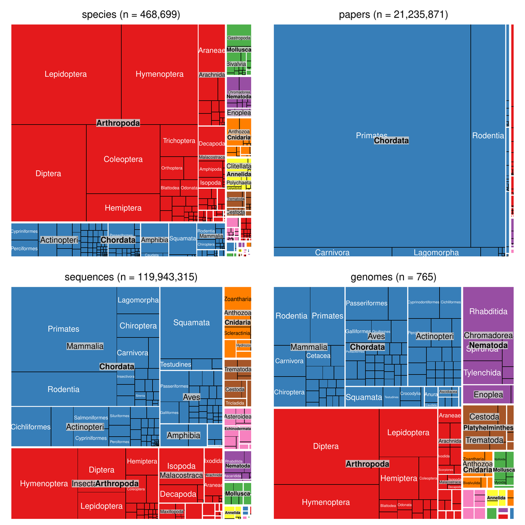

## 5 Continued development of *rentrez*

*rentrez* covers the complete eUtils API, is well-documented at the function and package level and includes an extensive test suite that covers internal functions as well as typical use-cases of the software. The current version of *rentrez* is thus considered a stable release, and it is unlikely any additional functionality will be added. The software is nevertheless still actively maintained to keep pace with CRAN and NCBI policies and to fix any bugs that arise. Software issues, including bug reports and requests for help with particular use-cases, are welcomed at the package’s software repository: http://github.com/ropensci/rentrez.

## 6 Acknowledgements

Development of *rentrez* has benefited greatly from being part of the rOpenSci project. I am especially grateful to Scott Chamberlain for his guidance. I am also very grateful to everyone who has provided pull-requests or filed issues including Chris Stubben, Karthik Ram, Han Guangchun, Matthew O’Meara, Reed Cartwright and Pavel Fedotov.

## 7 Appendix

Code used to produce Figure 1, using `animal_orders` data generated above.

```r
# Format the total number of records for a graph title
make_title <- function(col_name, data){
    n <- sum(data[,col_name])
    with_commas <- formatC(n, format = "d", big.mark = ",")
    paste0(col_name, " (n = ", with_commas, ")")
}

# Generate a treemap from taxonmic data.frame
# * data= tidy_taxonomy data.frame
# * size_col = name of column for tm tile-size
# * fill_col = name of column for tile-fil
# * row = plot row in 2x2 grid
# * col = plot col in 2x2 grid
# * pal = palette for fill
taxic_diversity_tm <- function(data, size_col, fill_col, row, col, pal){
    treemap(data,
        index=c("phylum", "class", "order"), vSize=size_col, vColor=fill_col,
        palette=pal, type='categorical', position.legend="none",
        title=make_title(size_col, data), border.col=c("white","white","black"),
        vp = viewport(layout.pos.row = row, layout.pos.col = col)
    )
}

library(treemap)
library(grid)
library(gridExtra)
# 24 phyla means some fill-colours will be re-used, ordering phylum factor by spp
# will prevent any "major" phyla from getting the same colour.
spp_per_phylum <- aggregate(species ~ phylum, FUN=sum, data=animal_orders)
phyla_ordered <- spp_per_phylum$phylum[ order(spp_per_phylum$species, decreasing=TRUE)]
animal_orders$phylum<- factor(animal_orders$phylum, levels=phyla_ordered)
pal <-  rep(RColorBrewer::brewer.pal(8, name="Set1"), 3)

grid.newpage()
pushViewport(viewport(layout = grid.layout(2, 2)))

taxic_diversity_tm(animal_orders, "species",   "phylum", 1,1, pal)
taxic_diversity_tm(animal_orders, "papers",    "phylum", 1,2, pal)
taxic_diversity_tm(animal_orders, "sequences", "phylum", 2,1, pal)
taxic_diversity_tm(animal_orders, "genomes",   "phylum", 2,2, pal)
```

### 7.1 Supplementary materials

Supplementary materials are available in addition to this article. It can be downloaded at RJ-2017-058.zip

### 7.2 CRAN packages used

ape, RISmed, pubmed.mineR, rentrez, reutils, rotl, fulltext, treemap

### 7.3 CRAN Task Views implied by cited packages

Environmetrics, OfficialStatistics, Phylogenetics, WebTechnologies

### 7.4 Bioconductor packages used

genomes, RMassBank, MeSHSim, genbankr

G. Becker and M. Lawrence. *Genbankr: Parsing GenBank files into semantically useful objects.* 2017. R package version 1.2.1.

S. Chamberlain. *Fulltext: Full text of ’scholarly’ articles across many data sources.* 2016. URL https://CRAN.R-project.org/package=fulltext. R package version 0.1.8.

S. Kovalchik. *RISmed: Download content from NCBI databases.* 2017. URL https://CRAN.R-project.org/package=RISmed. R package version 2.1.7.

F. Michonneau, J. W. Brown and D. J. Winter. rotl: An R package to interact with the open tree of life data. *Methods in Ecology and Evolution*, 7(12): 1476–1481, 2016. URL https://doi.org/10.1111/2041-210x.12593.

E. Paradis, J. Claude and K. Strimmer. APE: Analyses of phylogenetics and evolution in R language. *Bioinformatics*, 20: 289–290, 2004.

J. Rani, S.Ramachandran and Ab. R. Shah. *An r package for text mining of PubMed abstracts.* 2014. R package version 1.0.5.

E. Sayers and D. Wheeler. *Building customized data pipelines using the entrez programming utilities (eUtils).* NCBI, 2004.

G. Schöfl. *Reutils: Talk to the NCBI EUtils.* 2016. URL https://CRAN.R-project.org/package=reutils. R package version 0.2.3.

M. A. Stravs, E. L. Schymanski, H. P. Singer and J. Hollender. Automatic recalibration and processing of tandem mass spectra using formula annotation. *Journal of Mass Spectrometry*, 48(1): 89–99, 2013.

C. Stubben. *Genomes: Genome sequencing project metadata.* 2015. R package version 3.4.0.

M. Tennekes. *Treemap: Treemap visualization.* 2017. URL https://CRAN.R-project.org/package=treemap. R package version 2.4-2.

H. Wickham. Tidy data. *The Journal of Statistical Software*, 59: 2014. URL http://www.jstatsoft.org/v59/i10/.

J. Zhou and Y. Shui. *MeSHSim: MeSH(medical subject headings) semantic similarity measures.* 2015. R package version 1.6.0.

[^1]: http://www.genenames.org/